# 10X Analysis Template: GEX analysis

Kirsten Diggins

10X analysis with Seurat and Monocle3 - references: Monocle3: https://cole-trapnell-lab.github.io/monocle3/docs/starting/ Seurat: https://satijalab.org/seurat/vignettes.html

## Workflow:

1. Load data through Seurat and perform preliminary QC analysis.
2. Convert Seurat object to a cell data set (cds) object for use with Monocle3
3. Normalize and reduce dimensions, then plot to identify any batch effects or other quality issues.
4. Apply batch correction, gate out “junk” or unwanted cells.
5. Rerun dimensionality reduction, cluster data, and run trajectory analysis.
6. Find top markers per cluster.

## Load data and perform preliminary QC

```r
library(dplyr)
library(Seurat)
library(patchwork)
library(monocle3)
library(scater)
library(apird)
library(stringr)
library(ggpubr)
library(gridExtra)
library(car)
library(lme4)
library(garnett)
library(ggrepel)

# file.path = "output directory path/"
file.path = "Z:/workspace/mrosasco/200713-10XT1DALRvsNR3Batches_P362-1/P362-1_T1DAL_CRv4NoAdapter_aggrNoNorm/outs/"

## High contrast color palette
pal = toupper(c('#a6cee3','#1f78b4','#b2df8a','#33a02c','#fb9a99','#e31a1c','#fdbf6f','#ff7f00','#cab2d6','#6a3d9a','#ffed6f','#b15928'))

## Define list of known genes of interest
gene_list <- c("TIGIT","KLRG1","CCR7","TCF7")
```

```r
lib_IDs <- apird::getProjectLibs("P362-1")
P362_anno <- apird::getAnno(lib_IDs)

all.data <- Read10X(paste0(file.path,"filtered_feature_bc_matrix")) ## reads output of cellranger pipeline and returns UMI count matrix
aggr <- CreateSeuratObject(counts = all.data, min.features = 100, min.cells = 3, project = "P362-1")
```

```
Feature names cannot have underscores ('_'), replacing with dashes ('-')
```

min.features = includes cells where n features are detected; min.cells = include features detected in at least n cells.

```r
dim(aggr[["RNA"]]@counts)
```

```
[1] 22771 53488
```

```r
## number of genes x cells
```

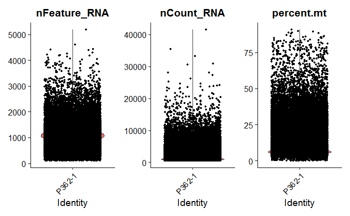

```r
## Add mitochondrial gene % to metadata
aggr[["percent.mt"]] <- PercentageFeatureSet(aggr, pattern = "^MT-")

VlnPlot(aggr,
        features = c("nFeature_RNA", "nCount_RNA", "percent.mt"),
        ncol = 3)
```

Choose thresholds based on quality plots. An alternative to a hard cutoff on percent.mt is to manually gate out the percent.mt-high population from the UMAP plot.

```r
aggr_postQC <- subset(aggr,
                      subset = nFeature_RNA > 200 & nFeature_RNA < 2500 & percent.mt < 20) ## This is the object I convert to cds for monocle3

aggr_postQC_norm <- NormalizeData(aggr_postQC, normalization.method = "LogNormalize", scale.factor = 10000)
```

## Run additional QC and convert to cds object for Monocle3

Convert the Seurat object to a cds object to perform downstream analysis in Monocle3.

```r
## Merge all metadata and annotations
metadata <- read.csv(file=paste0(file.path,"aggregation.csv")) %>%
  merge(P362_anno,by.x="library_id",by.y="libid")

### Add metadata to the Seurat object
gemgroup <- sapply(strsplit(rownames(aggr_postQC@meta.data), split="-"), "[[", 2)

aggr_postQC <- AddMetaData(object=aggr_postQC,
                    metadata=data.frame(gemgroup=gemgroup,
                                        Lib.ID=metadata[gemgroup,"library_id"],
                                        Donor.ID=metadata[gemgroup,"participantID"],
                                        Pool = metadata[gemgroup,"pool"],
                                        Timepoint = metadata[gemgroup,"timepoint"],
                                        Response = metadata[gemgroup,"response"],
                                        Date.Collected = metadata[gemgroup,"dateCollected"],
                                        row.names=rownames(aggr_postQC@meta.data)))

allmetadata = aggr_postQC@meta.data
```

Seurat QC plots:

```r
aggr_postQC_norm <- FindVariableFeatures(aggr_postQC_norm, selection.method = "vst", nfeatures = 2000)
# Identify the 10 most highly variable genes
top10 <- head(VariableFeatures(aggr_postQC_norm), 10)

# plot variable features with and without labels
plot1 <- VariableFeaturePlot(aggr_postQC_norm)
plot2 <- LabelPoints(plot = plot1, points = top10, repel = TRUE)
```

```
When using repel, set xnudge and ynudge to 0 for optimal results
```

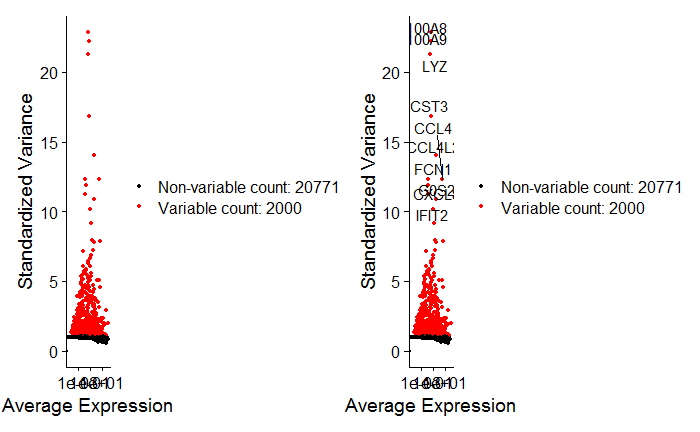

```r
plot1 + plot2
```

```r
aggr_postQC_norm <- ScaleData(aggr_postQC_norm) ## Default uses only the variable features; can specify all features but it will take a long time
#
aggr_postQC_norm <- RunPCA(aggr_postQC_norm, features = VariableFeatures(object = aggr_postQC_norm))
```

```
PC_ 1
Positive:  NKG7, B2M, PFN1, TMSB10, SH3BGRL3, S100A4, GZMH, CCL5, GAPDH, CST7
       CTSW, CD52, TMSB4X, ACTB, CFL1, ITGB2, SERF2, S100A6, HCST, FGFBP2
       GZMB, IL32, IFITM1, GZMA, CD74, FTL, PSME1, LY6E, HLA-DPA1, CLIC1
Negative:  TNFAIP3, FOSB, PABPC1, FOS, MT-RNR2, TSPYL2, IL7R, ZNF331, CCR7, ZEB1
       NELL2, JUNB, CAMK4, SESN3, SNX9, JUN, NR4A2, HSPH1, ABLIM1, NEK1
       ZFP36L2, ZNF10, XIST, SCML1, SPTBN1, SERINC5, FOXP1, IRS2, NR4A3, AGPAT5
PC_ 2
Positive:  DUSP1, FOS, LTB, FTH1, ZFP36, ZFP36L2, RPLP0, KLRB1, CSRNP1, NINJ1
       TUBB4B, JUNB, RPLP1, RPL13, BTG1, PABPC1, YPEL5, AQP3, TPT1, RPS8
       DDIT4, GADD45B, HSP90AB1, CXCR4, CCR6, LDHA, RPS2, CREM, DNAJB1, DUSP2
Negative:  GZMH, FGFBP2, GZMB, ZEB2, CCL4, NKG7, SYNE1, ZBP1, ENC1, CCL3
       GNLY, CCL5, IFNG, ADGRG1, CMC1, HLA-DPB1, NEAT1, CEP78, LGALS1, PRSS23
       C1orf21, MT-RNR1, MT-RNR2, TTC38, HLA-DPA1, ITGB2, CCL4L2, F2R, KLRD1, SLA2
PC_ 3
Positive:  LDHB, PASK, JUNB, MAL, AIF1, RGS10, CCR7, RHOH, RPS8, RPL13
       LINC02446, FOXP1, NELL2, C1orf228, CD8B, COTL1, LEF1, RPS18, TPT1, ACTG1
       FYB1, RPLP1, TMSB10, HSPB1, SPINT2, RPS26, GPSM3, PCED1B-AS1, LYPD3, RPS2
Negative:  KLRB1, BHLHE40, SLC7A5, AQP3, NKG7, CCR6, CEBPD, ERN1, TLE1, LDHA
       CA2, ZBTB16, SPOCK2, GTF3C1, GNLY, ADRB2, PTPRE, MAF, PDE4D, PPP1R14B
       N4BP3, TRBV6-4, NCR3, MT-RNR1, CXCR6, LUZP1, TNFAIP3, TYROBP, FURIN, ELOVL4
PC_ 4
Positive:  NR4A2, KLF6, TNFAIP3, RNF19A, OASL, DUSP4, NEAT1, NR4A3, SLC2A3, HLA-DRB1
       MCL1, TSPYL2, IFRD1, SAMSN1, ADGRE5, CD69, HLA-DRB5, RGCC, ZC3HAV1, PMAIP1
       HSPH1, LMNA, ANXA1, ZNF331, TUBA4A, ZEB2, HLA-DRA, PTGER4, EZR, NOCT
Negative:  RPS8, RPLP1, RPL13, RPS18, TPT1, RPS2, RPLP0, RPS4Y1, RPS26, FTL
       KLRB1, RPL13P12, LTB, TMSB10, AQP3, RPS2P5, S100A6, CCR6, NOSIP, NCR3
       TRBV6-4, PPIA, TLE1, S100A4, BLK, HIST1H4C, TXNIP, CEBPD, SH3BGRL3, PCED1B-AS1
PC_ 5
Positive:  TUBA4A, TUBB4B, ZFP36, NR4A2, CCL5, TSC22D3, C20orf24, JUNB, IER2, KLF2
       CXCR4, DUSP1, CCL4, GNLY, GADD45B, GZMB, XCL1, FGFBP2, BTG1, FTL
       NKG7, ZFP36L2, FTH1, DUSP2, TUBA1B, OASL, NFKBIA, CSRNP1, CITED2, HIST1H4C
Negative:  LST1, LYZ, S100A9, AIF1, S100A8, FCN1, SPI1, FCER1G, HLA-DRA, PLAUR
       G0S2, CST3, CLEC7A, IFNGR2, SERPINA1, THBS1, TYMP, HBEGF, CSTA, CFD
       CEBPD, CXCL8, MAFB, GRN, S100A12, CTSH, CTSD, ARPC1B, LGALS3, GPX1
```

```r
print(aggr_postQC_norm[["pca"]], dims = 1:5, nfeatures = 5)
```

```
PC_ 1
Positive:  NKG7, B2M, PFN1, TMSB10, SH3BGRL3
Negative:  TNFAIP3, FOSB, PABPC1, FOS, MT-RNR2
PC_ 2
Positive:  DUSP1, FOS, LTB, FTH1, ZFP36
Negative:  GZMH, FGFBP2, GZMB, ZEB2, CCL4
PC_ 3
Positive:  LDHB, PASK, JUNB, MAL, AIF1
Negative:  KLRB1, BHLHE40, SLC7A5, AQP3, NKG7
PC_ 4
Positive:  NR4A2, KLF6, TNFAIP3, RNF19A, OASL
Negative:  RPS8, RPLP1, RPL13, RPS18, TPT1
PC_ 5
Positive:  TUBA4A, TUBB4B, ZFP36, NR4A2, CCL5
Negative:  LST1, LYZ, S100A9, AIF1, S100A8
```

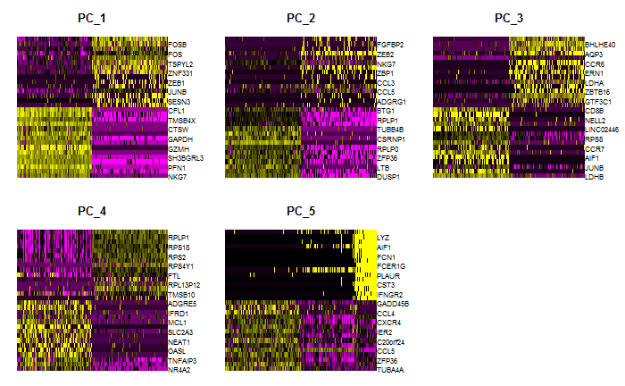

```r
DimHeatmap(aggr_postQC_norm, dims = 1:5, cells = 500, balanced = TRUE)
```

```r
###### Create cds object

## For today's example, I'm taking a random sample to speed up the downstream steps (~10%)
aggr_postQC <- aggr_postQC[,sample(colnames(aggr_postQC_norm),4000,replace = F)]

# ## Expression matrix
final_matrix = GetAssayData(aggr_postQC,assay="RNA",slot="counts") ## get raw counts from seurat object

## Filter cells and genes according to QC thresholds
keep_genes = row.names(final_matrix)
keep_cells = colnames(final_matrix)

## Cell meta data
final_meta_data = allmetadata[keep_cells,]
final_meta_data$Percent.MT <- aggr_postQC$percent.mt

## Gene meta data
final_gene_data = data.frame(gene_short_name = keep_genes)
row.names(final_gene_data) <- row.names(final_matrix)

## Combine into cell data set object
cds <- new_cell_data_set(final_matrix,
                         cell_metadata = final_meta_data,
                         gene_metadata = final_gene_data)
```

## Process data and perform additional QC

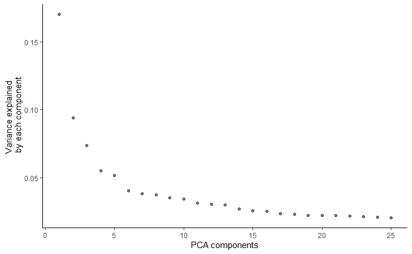

```r
cds <- preprocess_cds(cds, num_dim = 25) ## default applies log normalization; PCA down to input num_dim
plot_pc_variance_explained(cds)
```

```
No trajectory to plot. Has learn_graph() been called yet?
Cells aren't colored in a way that allows them to be grouped.
No trajectory to plot. Has learn_graph() been called yet?
```

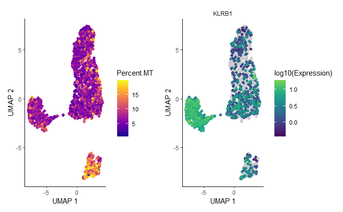

```r
cds <- reduce_dimension(cds,preprocess_method = "PCA") ## default dim red is UMAP
colData(cds)$Percent.MT <- aggr_postQC@meta.data$percent.mt
plot_cells(cds,color_cells_by="Percent.MT",cell_size=1.5) +
  plot_cells(cds,genes="KLRB1",cell_size=1.5)## Plot by clinical or technical features to identify any batch effects or other quality issues.
```

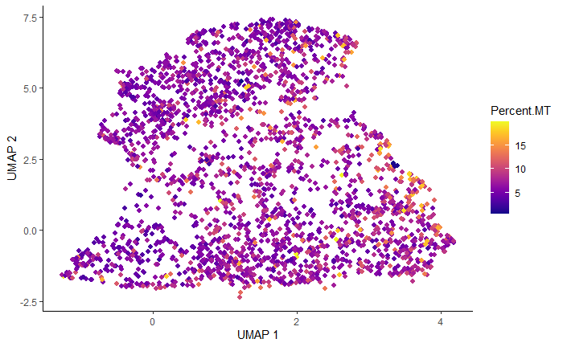

```r
cds_post_QC <- choose_cells(cds)  ## exclude high Percent.MT cells if not excluded during Seurat pre-processing

plot_cells(cds_post_QC,
           color_cells_by = "Percent.MT",
           label_cell_groups = F,
           cell_size=1.5)
```

```
No trajectory to plot. Has learn_graph() been called yet?
```

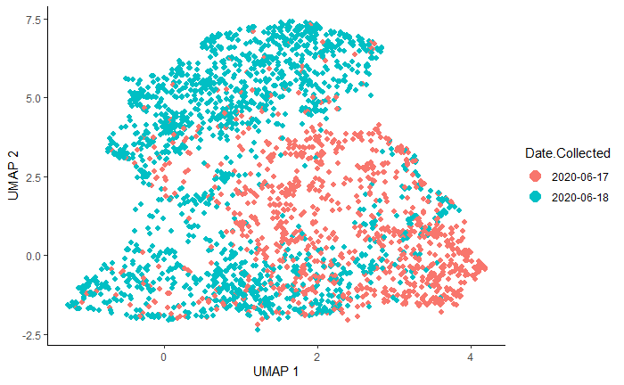

```r
# cds_post_QC <- choose_cells(cds)  ## exclude high Percent.MT cells if not excluded during Seurat pre-processing

plot_cells(cds_post_QC,
           color_cells_by = "Date.Collected",
           label_cell_groups = F,
           cell_size=1.5)
```

```r
## Remove batch effects
## Use residual_model_formula_string for continuous variable batch correction, and alignment_group for discrete variables
cds_batch_corrected = align_cds(cds_post_QC,
                                preprocess_method = "PCA",
                                alignment_group = "Date.Collected") #, residual_model_formula_str = "~Percent.MT")
```

```
Aligning cells from different batches using Batchelor.
Please remember to cite:
     Haghverdi L, Lun ATL, Morgan MD, Marioni JC (2018). 'Batch effects in single-cell RNA-sequencing data are corrected by matching mutual nearest neighbors.' Nat. Biotechnol., 36(5), 421-427. doi: 10.1038/nbt.4091
```

```r
cds_batch_corrected <- reduce_dimension(cds_batch_corrected,reduction_method = "UMAP") ## reduce dimensions of batch corrected data
```

```
No preprocess_method specified, and aligned coordinates have been computed previously. Using preprocess_method = 'Aligned'
```

```
No trajectory to plot. Has learn_graph() been called yet?
```

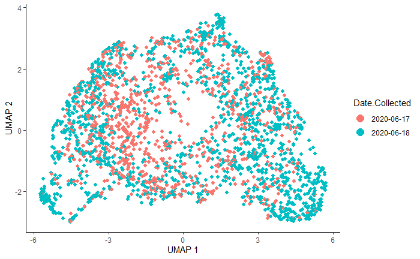

```r
plot_cells(cds_batch_corrected,
           color_cells_by="Date.Collected",
           label_cell_groups = F,
           cell_size=1.5) ## check batch correction
```

## Cluster and run trajectory analysis

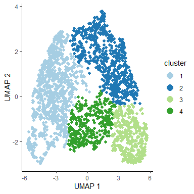

```r
# cds_to_plot <- choose_cells(cds_batch_corrected) ## Optional - gate to further subset cells for clustering, dim red, trajectory, DE expression analysis

cds_batch_corrected <- cluster_cells(cds_batch_corrected,
                                     resolution = 1e-3) ## resolution determines cluster number; high resolution --> more clusters

plot_cells(cds_batch_corrected,
           color_cells_by="cluster",
           show_trajectory_graph = F,
           label_cell_groups = F,
           cell_size=1.5) +
  scale_color_manual(values=c(pal))
```

```
`select_()` is deprecated as of dplyr 0.7.0.
Please use `select()` instead.
Please use the `.add` argument instead.
```

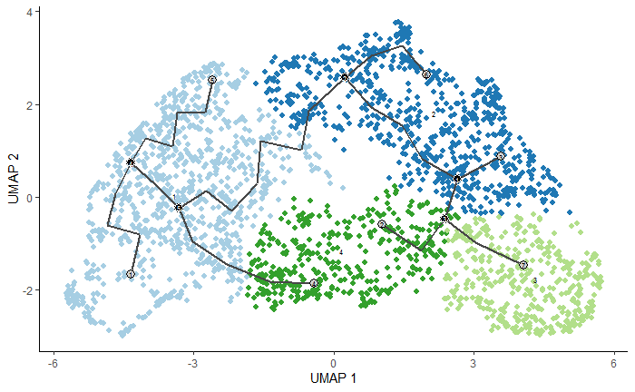

```r
## Run trajectory analysis - ncenter and minimal_branch_len can be adjusted to modify trajectory; fewer centers results in a more simplified trajectory
cds_batch_corrected <- learn_graph(cds_batch_corrected,
                                   use_partition=F, close_loop=F,
                                   learn_graph_control=list(ncenter=50, minimal_branch_len = 3))

plot_cells(cds_batch_corrected,
           color_cells_by="cluster",
           show_trajectory_graph = T,
           cell_size = 1.5) +
  scale_color_manual(values=c(pal))
```

```r
## Specify beginning of pseudotime in trajectory:
# cds_batch_corrected <- order_cells(cds_batch_corrected)
```

After running the trajectory analysis, you may want to renumber clusters to follow a more intuitive order. This can be done with recode.

```r
## Recode clusters according to order along trajectory
# colData(cds_batch_corrected)$cluster <- as.factor(dplyr::recode(colData(cds_batch_corrected)$cluster,
#                                                  "4" = 1,
#                                                  "2" = 2,
#                                                  "1" = 3,
#                                                  "3" = 4,
#                                                  "5" = 5,
#                                                  "6" = 6))
```

## Find top markers defining each cluster

```r
## Plot heatmap of top markers per cluster
```

```
There were 16 warnings (use warnings() to see them)
```

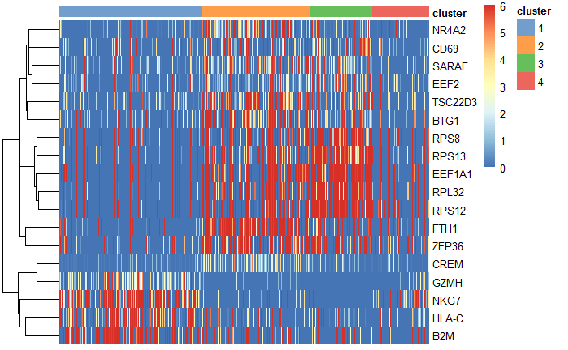

```r
plotHeatmap(cds_batch_corrected,
            order_columns_by="cluster",
            # cluster_cols = T,
            exprs_values = 1,
            by_exprs_values = 1,
            center=T,
            zlim = c(0,6),
            features=unique(top_specific_markers$gene_id),
            show_colnames = F)
```

# Additional plots for data exploration:

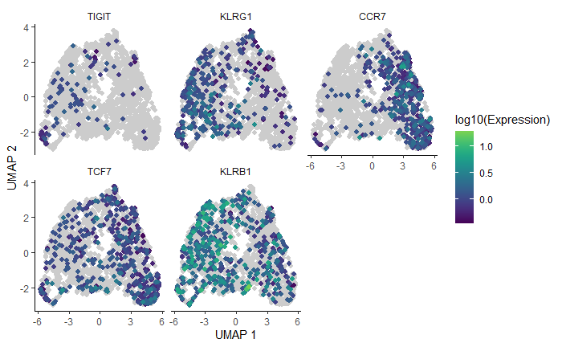

```r
## Plot cells in UMAP space and color by gene(s)
plot_cells(cds_batch_corrected,
           genes=c(gene_list,"KLRB1"),
           label_cell_groups = F,
           show_trajectory_graph = F,
           cell_size=1.5)
```

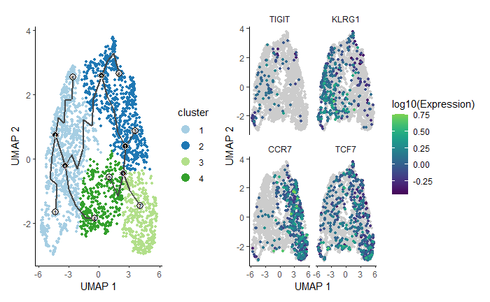

```r
## Plot clusters alongside genes on UMAP
plot_cells(cds_batch_corrected,
           color_cells_by = "cluster",
           label_cell_groups = F,
           show_trajectory_graph = T,
           cell_size = 1) + scale_color_manual(values=c(pal)) +
  plot_cells(cds_batch_corrected,
             genes = gene_list,
             show_trajectory_graph = F,
             cell_size=1,
             label_cell_groups = F)
```

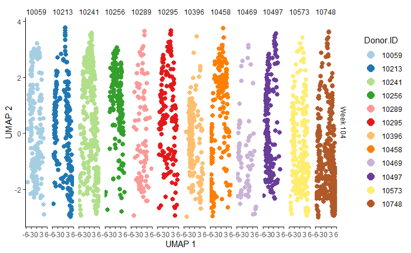

```r
## Plot UMAP by group with facet grid to split cells out by group (e.g. Donor.ID or time point)
plot_cells(cds_batch_corrected,
           color_cells_by="Donor.ID",
           label_cell_groups = F,cell_size=2,
           show_trajectory_graph = F) +
  facet_grid(cols=vars(Donor.ID),
             rows=vars(Timepoint)) +
  scale_color_manual(values=c(pal))
```

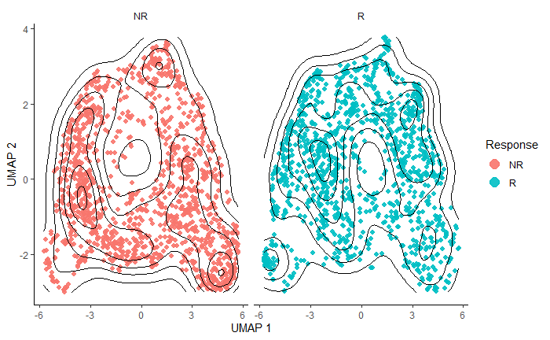

```r
## Plot UMAP with density contours, split out by variable (e.g. clinical group or time point)
plot_cells(cds_batch_corrected,
           color_cells_by = "Response",
           show_trajectory_graph = F,
           cell_size = 1.5,
           alpha = 0.9,
           label_cell_groups = F) + facet_wrap(~ Response, ncol=3) + geom_density2d(colour="black")
```

```
the condition has length > 1 and only the first element will be used
```

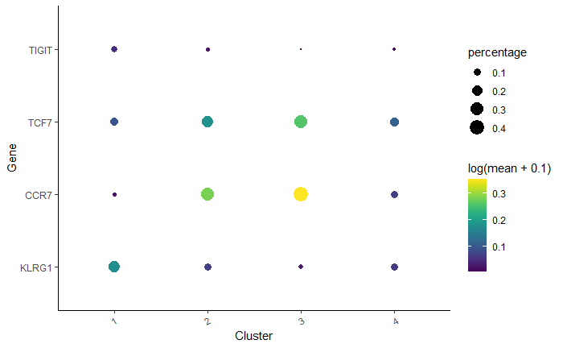

```r
## Dot plot of gene expression by group or cluster
plot_genes_by_group(cds_batch_corrected,
                    gene_list,
                    group_cells_by="cluster",
                    ordering_type="maximal_on_diag",
                    max.size=6)
```

```r
## Save cds object for future analysis. This saved cds object is used as input for 10X TCR analysis template.
# save(cds_batch_corrected,file=paste0(file.path,"cds_object.Rdata"))
```

### DGEA analysis with Seurat

```r
## Subset seurat aggr for genes and cells and add back cluster info
aggr_postQC_norm@meta.data$barcode = row.names(aggr_postQC_norm@meta.data)

seurat_subset <- subset(aggr_postQC_norm, subset = barcode %in% colnames(cds_batch_corrected), features=row.names(cds_batch_corrected))

# ## Add back cluster ID from monocle3
seurat_cell_barcodes <- seurat_subset@meta.data %>% as.data.frame() %>% dplyr::select(barcode)
colData(cds_batch_corrected)$barcode <- colnames(cds_batch_corrected)
#
seurat_barcodes_anno <- colData(cds_batch_corrected) %>%
  as.data.frame() %>%
  dplyr::select(cluster, barcode) %>%
  merge(seurat_cell_barcodes,by="barcode") %>%
  arrange(match(barcode,seurat_cell_barcodes$barcode))
#
seurat_subset@meta.data$cluster <- seurat_barcodes_anno$cluster

Idents(seurat_subset) <- seurat_subset@meta.data$cluster
```

```r
## Run DGEA in Seurat comparing clusters
cluster.markers <- FindMarkers(seurat_subset, ident.1 = 1, ident.2 = 2, min.pct = 0.1, logfc.threshold = 0.25, min.diff.pct = 0)# %>%
  # dplyr::filter(p_val_adj < 0.01) ## filter by sig threshold
# cluster.markers
```

```r
cluster.markers.subset <- cluster.markers %>% dplyr::filter(avg_logFC > 0.2, p_val_adj < 0.01)
# write.csv(cluster.markers.subset,paste0(file.path,"gene list.csv")) ## save for string-db or other pathway analysis
```

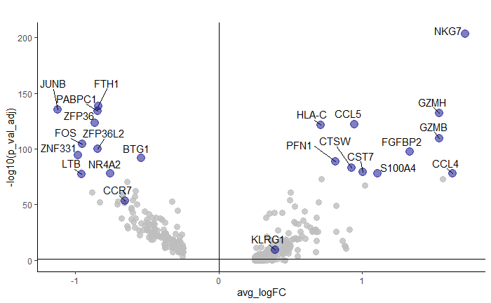

```r
## Volcano plot for cluster contrast
all_gene_labels <- c(gene_list)

cluster.markers$label.gene <- row.names(cluster.markers) %in% c(row.names(dplyr::filter(cluster.markers,-log10(p_val_adj) > 75, avg_logFC < -0.2 | avg_logFC > 0.2)),all_gene_labels)
cluster.markers.to.label <- dplyr::filter(cluster.markers,label.gene==1)
cluster.markers.no.label <- dplyr::filter(cluster.markers,label.gene==0)


ggplot(cluster.markers.no.label,aes(x=avg_logFC, y=-log10(p_val_adj))) +
  geom_point(size=3,color="gray",alpha=0.8) +
  geom_point(data = cluster.markers.to.label,
             aes(x=avg_logFC, y=-log10(p_val_adj)),
             size=4,color="darkblue",alpha=0.5) +
  geom_text_repel(data = cluster.markers.to.label,
            aes(x=avg_logFC, y=-log10(p_val_adj),
                label=rownames(cluster.markers.to.label)),nudge_y = 10,nudge_x=-0.05) +
  geom_hline(yintercept = 1.3) + geom_vline(xintercept = 0) +
  labs(title="   ") +
  theme_classic()
```